# Data Analysis: Educational Lab

### 2.1 Converting the "timestamp" Column

First, we'll discuss more complicated cases, like the one addressed below, but in general, the `astype()` method – which we'll talk about later – is a common way to convert the data type of a column. For a basic task like ours, this explanation is sufficient.

In the `timestamp` column, the data includes date and time information. Whatever approach is adopted, it will need to handle different date formats, such as day/month/year, month/year/day, with or without hour information.

For this project, we won't extensively correct the data in this column, as that would go beyond the simplified scope we aim to present here. However, we'll make some relevant and interesting considerations and provide, as an illustrative example, a conversion. Read carefully:

When dealing with data that involves dates and times, we enter territory that can be filled with challenges and complexities. Handling this data is not as trivial as it may seem at first glance. Here are some reasons why data related to dates and times can pose considerable difficulties in its manipulation/transformation.

**Various Formats**: Dates can be presented in various formats, such as "day/month/year" or "year/month/day," and times may or may not include seconds. The variety of representations adds complexity to the conversion process.

**Missing or Inconsistent Data**: Often, datasets may contain missing or inconsistently formatted dates. This can result in errors during the conversion to a standard format.

**Time Zones**: In global environments, the presence of different time zones can further complicate the correct interpretation of dates and times, especially if this information is not clearly defined.

**Presence of Additional Text**: Sometimes, dates and times can be "mixed" with other text data, requiring careful separation and conversion of this information.

**Precision and Granularity**: Depending on the context, it may be necessary to work with different levels of temporal precision, such as days, hours, minutes, or even seconds. The precise manipulation of these levels of granularity adds layers of complexity.

It is crucial to recognize that the process of transforming data like that present in the `timestamp` column can be significantly challenging and present different levels of complexity. In real-world situations, a comprehensive analysis of dates and times often involves detailed considerations and advanced methods.

In our current work, we are focusing on more basic concepts to provide a solid understanding, but it is important to be aware that handling dates and times can become an extensive and specialized journey.

Let's consider the unique values present in our column:

```python
df['timestamp'].unique()
```

```
array(['8/7/2020 12:02', '8/7/2020 12:04', '8/7/2020 12:05',
       '8/7/2020 12:06', '8/7/2020 12:13', '8/7/2020 12:31',
       '8/7/2020 12:32', '8/7/2020 12:33', '8/7/2020 12:35',
       '8/7/2020 12:39', '8/7/2020 12:40', '8/7/2020 12:41',
       '8/7/2020 12:43', '8/7/2020 12:46', '8/7/2020 12:52',
       '8/7/2020 13:05', '8/7/2020 13:07', '8/7/2020 13:12',
       '8/7/2020 13:13', '8/7/2020 13:15', '8/7/2020 13:17',
       '8/7/2020 13:29', '8/7/2020 13:35', '8/7/2020 13:41',
       '8/7/2020 13:58', '8/7/2020 14:05', '8/7/2020 14:27',
       '8/7/2020 14:29', '8/7/2020 14:31', '8/7/2020 14:41',
       '8/7/2020 14:43', '8/7/2020 14:45', '8/7/2020 14:47',
       '8/7/2020 14:56', '8/7/2020 14:57', '8/7/2020 14:58',
       '8/7/2020 15:07', '8/7/2020 15:08', '8/7/2020 15:09',
       '8/7/2020 15:12', '8/7/2020 15:14', '8/7/2020 15:18',
       '8/7/2020 15:27', '8/7/2020 15:37', '8/7/2020 15:47',
       '8/7/2020 15:48', '8/7/2020 15:57', '8/7/2020 15:58',
       '8/7/2020 16:08', '8/7/2020 16:21', '8/7/2020 16:22',
       '8/7/2020 16:34', '8/7/2020 16:53', '8/7/2020 17:05',
       '8/7/2020 17:37', '8/7/2020 17:46', '8/7/2020 17:50',
       '8/7/2020 18:10', '8/7/2020 18:11', '8/7/2020 19:05',
       '8/7/2020 19:32', '8/7/2020 20:36', '8/7/2020 21:21',
       '8/7/2020 22:35', '9/7/2020 6:57', '9/7/2020 11:43',
       '9/7/2020 11:57', '9/7/2020 13:15', '9/7/2020 18:24',
       '13/07/2020 10:07:32', '13/07/2020 10:10:30',
       '13/07/2020 10:11:26', '13/07/2020 10:12:18',
       '13/07/2020 10:12:26', '13/07/2020 10:12:28',
       '13/07/2020 10:14:46', '13/07/2020 10:33:47',
       '13/07/2020 10:34:08', '13/07/2020 11:46:13',
       '13/07/2020 11:49:02', '13/07/2020 11:54:58',
       '13/07/2020 13:57:11', '13/07/2020 14:38:12',
       '13/07/2020 14:48:05', '13/07/2020 16:15:13',
       '13/07/2020 17:30:44', '13/07/2020 19:08:32',
       '13/07/2020 19:56:49', '13/07/2020 21:21:42',
       '13/07/2020 21:22:56', '13/07/2020 21:23:57',
       '18/07/2020 20:16:21'], dtype=object)
```

When analyzing the unique values in the `timestamp` column, we observe some patterns and potential challenges that deserve attention:

Format D/M/Y and H:M: Most values follow the "day/month/year hour:minute" pattern, as exemplified by '8/7/2020 12:02'. This is good news as it indicates considerable uniformity.

Presence of Seconds: Some values, like '13/07/2020 10:07:32', include seconds information. This variation in format may require additional attention when performing conversion operations.

### Other potential issues

Variation in Separators: We could have a set of dates in which some values use slashes ("/") as separators while others use hyphens ("-"). This could be a potential source of complexity when standardizing the data.

When dealing with these challenges, we must define an approach that takes into account the variety of formats without compromising the quality of the conversion. Thus, it will be possible to adjust the strategy to ensure effective and correct data manipulation.

### Other considerations about date and time data

What happens if the list is extremely extensive? It becomes impractical and unproductive for the analyst to check value by value. When it comes to understanding the data structure in an extensive list, especially when dealing with it for the first time, analysts often adopt various approaches. Let's describe some possibilities without delving into each one in detail.

**Visualization of Initial Values**: Analysts often start by visualizing the initial values in the list to identify patterns and initial formats. This can provide initial insights into the data structure.

**Use of Descriptive Methods**: Applying descriptive methods, such as counting the frequency of different formats, can help identify predominant patterns and less common formats. Tools like the value_counts() function in pandas can be useful.

**Random Sampling**: In extensive datasets, analysts may choose to randomly sample a portion of the data for a more detailed analysis. This helps to get an overview without examining each value individually.

**Analysis of Differences and Variations**: When examining the list, analysts can look for variations in formats, such as the presence or absence of seconds, different separators, etc. This helps identify possible challenges in standardization.

**Use of Computational Tools**: Computational tools and methods, such as regular expressions, can be employed to identify specific patterns in the data. These tools are effective for dealing with extensive lists.

Don't worry about all this; it's work that should be done day by day and can be developed, mainly with practice. So, consider this information as a mental trigger for when you start delving into the content and truly transforming columns like this, already having some prior knowledge.

Later on, we present one of the possible approaches (simple for this case), which does not consider all the biases that could be encountered at the time of conversion (some biases were highlighted earlier).

In the following code, when using the parameter format='%d/%m/%Y %H:%M:%S', we specify the expected format for the data in the 'timestamp' column. This is done to handle different formats and ensure the correct interpretation of date and time values. The presence of NaT values (Not a Time) indicates that there were non-convertible or missing values, and the parameter errors='coerce' is useful to handle these situations without generating errors. In other words, if any value could not be converted, it would then be transformed into 'NaT'.

While this is an effective approach for the example, in practice, the variety of date and time formats may require a more in-depth analysis and perhaps even the use of regular expressions or more advanced methods.

```python
# Convert the 'momento_envio' column to datetime format, considering different formats
df['timestamp'] = pd.to_datetime(df['timestamp'], errors='coerce', format='%d/%m/%Y %H:%M:%S')

# Display the first rows of the DataFrame after the conversion
df['timestamp'].unique()
```

```
array([                          'NaT', '2020-07-13T10:07:32.000000000',
       '2020-07-13T10:10:30.000000000', '2020-07-13T10:11:26.000000000',
       '2020-07-13T10:12:18.000000000', '2020-07-13T10:12:26.000000000',
       '2020-07-13T10:12:28.000000000', '2020-07-13T10:14:46.000000000',
       '2020-07-13T10:33:47.000000000', '2020-07-13T10:34:08.000000000',
       '2020-07-13T11:46:13.000000000', '2020-07-13T11:49:02.000000000',
       '2020-07-13T11:54:58.000000000', '2020-07-13T13:57:11.000000000',
       '2020-07-13T14:38:12.000000000', '2020-07-13T14:48:05.000000000',
       '2020-07-13T16:15:13.000000000', '2020-07-13T17:30:44.000000000',
       '2020-07-13T19:08:32.000000000', '2020-07-13T19:56:49.000000000',
       '2020-07-13T21:21:42.000000000', '2020-07-13T21:22:56.000000000',
       '2020-07-13T21:23:57.000000000', '2020-07-18T20:16:21.000000000'],
      dtype='datetime64[ns]')
```

## 2.2 Converting the "current_sudy_year" column

Now we move on to conversions using the astype() method.

```python
df['current_study_year'] = df['current_study_year'].astype('category')
df['current_study_year'].unique()
```

```
['year 1', 'year 2', 'Year 1', 'year 3', 'year 4', 'Year 2', 'Year 3']
Categories (7, object): ['Year 1', 'Year 2', 'Year 3', 'year 1', 'year 2', 'year 3', 'year 4']
```

When converting the 'current_study_year' column to the categorical type and using the `unique()` method, we gained insight into the unique values present there. It is noticeable that there are variations in how the study years are represented, including different capitalizations (uppercase and lowercase).

To standardize these values, we can choose to convert all values to lowercase, for example, and then reassess the unique values to ensure consistency in representation. This can be done as follows:

```python
# Converte the current_study_year column to categorical type
df['current_study_year'] = df['current_study_year'].str.lower()

# Standardize values by converting to lowercase
df['current_study_year'] = df['current_study_year'].astype('category')

# Display unique values after conversion
df['current_study_year'].unique()
```

```
['year 1', 'year 2', 'year 3', 'year 4']
Categories (4, object): ['year 1', 'year 2', 'year 3', 'year 4']
```

With the conversion to the categorical type and the subsequent standardization of values to lowercase, we achieved consistency in the representation of study years. The performed conversion ensures uniformity in the data, consequently facilitating future analyses and interpretations. Now we will proceed with the conversion of the `cgpa` column, which will bring us additional challenges.

## 2.3 Converting the cgpa Column

Before we delve into discussing the conversion of data in the `cgpa` column, let's take a look at the unique values in the column to gain an understanding of how they are presented.

```python
df['cgpa'].unique()
```

```
array(['3.00 - 3.49', '3.50 - 4.00', '3.50 - 4.00 ', '2.50 - 2.99',
       '2.00 - 2.49', '0 - 1.99'], dtype=object)
```

### 2.3.1 CGPA Column: Dealing with Interval Values

While exploring the CGPA column, we noticed that the data is presented in a metric format, representing intervals such as '3.00 - 3.49', '3.50 - 4.00', etc. These intervals suggest specific ranges of Cumulative Grade Point Averages (CGPA), providing an overview of students' academic performance.

Now, to make these intervals more numerically meaningful, we will turn to the use of regular expressions (regex). Let's understand how this works:

#### Understanding Regular Expressions Simply:

Regular expressions, or regex, are character patterns that make it easier to search and manipulate texts. In the context of the CGPA column, where values are in the format '3.00 - 3.49', the simple regular expression `\d+\.\d+` helps us extract the numbers contained therein.

- \d: represents any digit from 0 to 9.
- +: indicates that the preceding character (in our case, \d) can appear one or more times.
- .: searches for a decimal point, preceded by a backslash to be interpreted literally.

Having said that, our next step is to convert these "textual intervals" into more representative numeric values. We understand that each interval covers a range of values, and to simplify the analysis, we will assume the average of this interval as its representative value. If you haven't grasped what this means yet, we will look for a value within the presented interval values, and this value will be the average between them.

##### Choosing the Right Technique:

As we've seen, the `cgpa` column has its data in textual (string) format, and we need to extract the numbers presented there. So, for extracting numbers from strings, using regular expressions is a common and powerful choice.

##### How to Use:

Understanding the pattern of the data we are trying to extract is helpful. In our case, the pattern was presented as we explained what regular expressions are. There are online resources and Python libraries, like re, that provide assistance in creating regular expressions. The intention is not to teach how to solve all possible cases, but to show the way data can be presented and how it impacts the choice of treatment in a given situation.

```python
# Importing the re library, which deals with regular expressions
import re

# Defining a function called calculate_mean
def calculate_mean(interval):
    # Using re.findall to find all decimal number patterns in the interval string
    found_numbers = re.findall(r'\d+\.\d+', interval)

    # Initializing an empty list to store the converted numbers
    converted_numbers = []

    # Iterating over each found number in the list
    for number in found_numbers:
        # Converting each number to the float data type and adding it to the converted_numbers list
        converted_numbers.append(float(number))

    # Calculating the mean of the numbers in the converted_numbers list
    mean = sum(converted_numbers) / len(converted_numbers)

    # Returning the calculated mean
    return mean

# Applying the calculate_mean function to the 'cgpa' column of the DataFrame df
df['cgpa'] = df['cgpa'].apply(calculate_mean)
```

```python
# Checking information about the 'cgpa' column
df[['cgpa']].info()
```

```
<class 'pandas.core.frame.DataFrame'>
RangeIndex: 101 entries, 0 to 100
Data columns (total 1 columns):
 #   Column  Non-Null Count  Dtype
---  ------  --------------  -----
 0   cgpa    101 non-null    float64
dtypes: float64(1)
memory usage: 940.0 bytes
```

The strategy used was designed in a didactic manner, aiming to facilitate understanding, especially for beginners. After applying this approach, we can observe that the "cgpa" column now displays the converted and properly handled values - check the DTYPE above in the line starting with a hashtag.

Keep in mind that the presented approaches reflect some real-world nuances that could not be addressed using conversion with the `astype()` method alone. However, to conclude this section, we provide a link to the official Pandas documentation, where you can find detailed information about the `astype()` method and its use for data type conversions:

[Method: astype() - Pandas Documentation](https://pandas.pydata.org/pandas-docs/stable/reference/api/pandas.DataFrame.astype.html)

# 3 - Standardization and Normalization

After exploring the identification and handling of missing data, as well as managing data types, we will now focus on standardization and normalization.

**Motivation**:

**Standardization** and **Normalization** ensure that variables are on comparable scales, eliminating potential biases in algorithms sensitive to the scale of data.

**Implications**:

- The absence of these processes can lead to distorted results, especially in algorithms that rely on distance measures or optimization.
- Standardization contributes to a more intuitive interpretation of model coefficients or weights, facilitating the analysis and understanding of results.

Let's consider an example:

Imagine the heights of two individuals, João and Maria, to understand how the lack of uniformity in scales can affect data interpretation.

João is 180 centimeters tall, while Maria is 160 centimeters tall. If we try to directly compare these numbers, it may seem like João is much taller than Maria. However, this conclusion could be misleading if we do not consider the natural variation in average heights among different groups of people. Each person is unique, and physical characteristics can vary independently of gender.

Imagine that we are using these heights in a dataset, like a large puzzle with many different pieces. Without standardization or normalization, we might face a challenge similar to trying to solve the puzzle using only one color, as if height were the only important piece.

Without these adjustment processes (normalization and standardization), our "rules" (or algorithms) can become a bit unbalanced, giving more importance to height than to other equally relevant characteristics, such as specific biological features. It's as if we were judging someone's ability solely based on height, completely ignoring their other unique characteristics.

Standardization and normalization play a relevant and essential role in comparing attributes, ensuring that all contribute equitably to the analyses. The absence of these processes can lead to biased conclusions, as some variables may exert disproportionate influence due to their original scales.

Standardization and normalization techniques not only facilitate the interpretation of results but also improve algorithm convergence, making the analysis more precise and meaningful.

In this way, our approach not only addresses data absence but also ensures that when comparing different characteristics, we are considering their contributions fairly and objectively.

Next, let's look at the practical application of standardization and normalization, using specific examples such as the "weight_kg," "height_cm," and "age" columns in our dataset.

### 3.1 - Data Standardization

In our original dataset, we did not identify a column that naturally required standardization. However, over time and with practice, we will develop sensitivity to discern which columns in a DataFrame may need this type of treatment.

To illustrate the concept of standardization practically, we chose to create fictitious columns for weight and height for each student. These fictional columns will serve as an opportunity to explore and explain the standardization process in an educational context. By adding these fictional variables, we simulate a scenario where standardization can be applied, allowing for a more tangible and understandable approach to this concept.

Here is a general example, using the NumPy library to create columns with random values for all rows in the dataset:

```
df['column_to_be_created'] = np.random.randint(min_value_in_column, max_value_in_column, size=num_rows)
```

```python
def add_fictional_column(df, column_name, min_value, max_value):
    """
    Adds a fictional column to the DataFrame with random values within a specific range.

    Parameters:
    - df: DataFrame
        The DataFrame to which the column will be added.
    - column_name: str
        The name of the column to be created.
    - min_value: int
        The minimum value for random values.
    - max_value: int
        The maximum value for random values.
    """
    np.random.seed(42)  # To ensure reproducibility
    df[column_name] = np.random.randint(min_value, max_value, size=len(df))

# Replace 'df' with the name of your DataFrame and add as many fictional columns as desired
# Example:
add_fictional_column(df, 'weight_kg', 50, 90)
add_fictional_column(df, 'height_cm', 150, 190)
```

To understand

```
np.random.seed(42)  # To ensure reproducibility
```

check: Understanding the Random Seed

Generalizing, standardization can be applied as follows:

```
df['standardized_column'] = (df['column_to_be_standardized'] - df['column_to_be_standardized'].mean()) / df['column_to_be_standardized'].std()
```

Now, let's standardize the columns`weight_kg` and `height_cm`.

```python
# Standardize the weight and height columns
df['standardized_weight'] = (df['weight_kg'] - df['weight_kg'].mean()) / df['weight_kg'].std()
df['standardized_height'] = (df['height_cm'] - df['height_cm'].mean()) / df['height_cm'].std()
```

```python
# Presenting a sample of the columns after standardization
df[['standardized_weight', 'standardized_height']].head()
```

|  | standardized_weight | standardized_height |
| --- | --- | --- |
| 0 | 1.667306 | 1.667306 |
| 1 | 0.797931 | 0.797931 |
| 2 | -0.419194 | -0.419194 |
| 3 | -1.027756 | -1.027756 |
| 4 | 0.102431 | 0.102431 |

Please note that the values obtained are less intuitive for humans and are more relevant and beneficial for machine learning algorithms.

**Here are some key points about the obtained data:**

**Facilitates Algorithm Training**:

- Machine learning algorithms often benefit from standardized data, as it can improve convergence during training. Standardization helps prevent features with very different scales from dominating the learning process.

**Comparability**:

- With standardization, features are placed on a common scale, making it easier to compare the relative importance of different features for the model.

**Human Interpretation**:

- To interpret results or present visualizations to a non-technical audience, it may be preferable to work with the original (non-standardized) data, as these values have more intuitive meanings. Standardization is often a preparatory step for modeling, but the final results can be presented in terms of the original features.

In summary, standardization in data preprocessing makes training more efficient and effective for machine learning algorithms. However, when communicating results to a broader audience, the original data may be more understandable and interpretable.

```python
df
```

|  | timestamp | gender | age | course | current_study_year | cgpa | marital_status | have_depression | have_anxiety | have_panic_attack | seek_specialist_for_treatment | weight_kg | height_cm | standardized_weight | standardized_height |
| --- | --- | --- | --- | --- | --- | --- | --- | --- | --- | --- | --- | --- | --- | --- | --- |
| 0 | NaT | Female | 18.0 | Engineering | year 1 | 3.245 | No | Yes | No | Yes | No | 88 | 188 | 1.667306 | 1.667306 |
| 1 | NaT | Male | 21.0 | Islamic education | year 2 | 3.245 | No | No | Yes | No | No | 78 | 178 | 0.797931 | 0.797931 |
| 2 | NaT | Male | 19.0 | BIT | year 1 | 3.245 | No | Yes | Yes | Yes | No | 64 | 164 | -0.419194 | -0.419194 |
| 3 | NaT | Female | 22.0 | Laws | year 3 | 3.245 | Yes | Yes | No | No | No | 57 | 157 | -1.027756 | -1.027756 |
| 4 | NaT | Male | 23.0 | Mathemathics | year 4 | 3.245 | No | No | No | No | No | 70 | 170 | 0.102431 | 0.102431 |
| ... | ... | ... | ... | ... | ... | ... | ... | ... | ... | ... | ... | ... | ... | ... | ... |
| 96 | 2020-07-13 19:56:49 | Female | 21.0 | BCS | year 1 | 3.750 | No | No | Yes | No | No | 57 | 157 | -1.027756 | -1.027756 |
| 97 | 2020-07-13 21:21:42 | Male | 18.0 | Engineering | year 2 | 3.245 | No | Yes | Yes | No | No | 61 | 161 | -0.680006 | -0.680006 |
| 98 | 2020-07-13 21:22:56 | Female | 19.0 | Nursing | year 3 | 3.750 | Yes | Yes | No | Yes | No | 83 | 183 | 1.232619 | 1.232619 |
| 99 | 2020-07-13 21:23:57 | Female | 23.0 | Pendidikan Islam | year 4 | 3.750 | No | No | No | No | No | 82 | 182 | 1.145681 | 1.145681 |
| 100 | 2020-07-18 20:16:21 | Male | 20.0 | Biomedical science | year 2 | 3.245 | No | No | No | No | No | 72 | 172 | 0.276306 | 0.276306 |

101 rows × 15 columns

It should also be noted that the weight and height columns from before standardization still remain in the data frame, with the option to either remove them or keep them, depending on the scope of the analysis and presentation to be performed.

Decision on Columns Post-Standardization - Keep or Remove?

### 3.2 - Data Normalization

We use normalization to compare quantities that exhibit different magnitudes or scales. This practice aims to place variables on a common scale, ensuring that none of them exerts a disproportionate influence on the analyses.

While exploring our dataset, we notice variables such as `age`, `weight_kg`, and `height_cm` that have different magnitudes. Normalization is a useful technique in this context as it allows us to compare and interpret these variables more intuitively and fairly.

Let's consider the following data for three students:

| Student | Age | Weight (kg) | Height (cm) |
| --- | --- | --- | --- |
| A | 18 | 70 | 180 |
| B | 22 | 65 | 160 |
| C | 19 | 75 | 170 |

**Without Normalization:**

- Comparing A's age (18) directly with B's height (160) does not provide a clear understanding of the actual difference between these variables.

**Normalization:** Normalization allows us to transform these variables into a comparable scale, facilitating interpretation and comparison. Let's normalize `age`, `weight_kg`, and `height_cm` using the formula:

`Normalized Value = (Original Value - Minimum Value) / (Maximum Value - Minimum Value)`

Applying this formula to our data, we get:

[output not shown]

**With Normalization:**

- Now, we can intuitively compare the three normalized variables for each student. The normalized age ranges from 0 to 1, as do weight and height, allowing for a "fairer" comparison.

By adopting normalization, we not only facilitate interpretation but also make the data more visually accessible, especially when different variables are involved. This practice contributes to more transparent analyses and more accurate interpretations.

```python
# Applying normalization to the columns age, weight_kg, height_cm
# Applying the normalization formula
df['normalized_age'] = (df['age'] - df['age'].min()) / (df['age'].max() - df['age'].min())
df['normalized_weight'] = (df['weight_kg'] - df['weight_kg'].min()) / (df['weight_kg'].max() - df['weight_kg'].min())
df['normalized_height'] = (df['height_cm'] - df['height_cm'].min()) / (df['height_cm'].max() - df['height_cm'].min())

df[['normalized_age', 'normalized_weight', 'normalized_height']]
```

|  | normalized_age | normalized_weight | normalized_height |
| --- | --- | --- | --- |
| 0 | 0.000000 | 0.974359 | 0.974359 |
| 1 | 0.500000 | 0.717949 | 0.717949 |
| 2 | 0.166667 | 0.358974 | 0.358974 |
| 3 | 0.666667 | 0.179487 | 0.179487 |
| 4 | 0.833333 | 0.512821 | 0.512821 |
| ... | ... | ... | ... |
| 96 | 0.500000 | 0.179487 | 0.179487 |
| 97 | 0.000000 | 0.282051 | 0.282051 |
| 98 | 0.166667 | 0.846154 | 0.846154 |
| 99 | 0.833333 | 0.820513 | 0.820513 |
| 100 | 0.333333 | 0.564103 | 0.564103 |

101 rows × 3 columns

# 4 - Visualization with Grouped Bar Charts (Binning)

Now, we will observe a step that aims to simplify the representation of continuous variables. Instead of dealing with individual values, binning organizes these values into discrete intervals or "bins". This approach facilitates the interpretation and visualization of data, allowing the identification of patterns and trends more clearly.

**Motivation**:

**Binning** is a fundamental stage that provides an organized way of dealing with continuous variables. This technique is especially useful in scenarios where categorizing information can result in substantial improvements.

**Implications**:

- The lack of binning can result in the loss of important information, especially when dealing with algorithms or analyses that benefit from clearer categorizations.
- Binning facilitates interpretation by grouping continuous values into intervals or "bins," making patterns more evident and simplifying the communication of results.

Next, we will explore the practical application of binning, using specific examples such as the variable "age," where we will divide the values of the age column into groups.

When performing binning, it is necessary to be careful in choosing appropriate interval ranges for the variable in question. The effectiveness of grouping depends directly on this selection, impacting subsequent interpretation. Let's explore the binning process in a generalized and didactic way.

To start, we will perform a simple distribution. The division into groups, such as "Young," "Young Adult," and "Adult," is arbitrary and was made based on equally spaced boundaries and does not reflect the actual ages contained in the data frame. This is a simplification for educational purposes, but in practice, the choice of bin limits can be more complex and based on exploratory data analysis.

```python
# Define the bins (intervals)
bins = np.linspace(min(df['age']), max(df['age']), 4)

# Define the group labels
group_names = ['Young', 'Young Adult', 'Adult']

# Apply binning to the 'age' column and create a new column 'binned_age'
df['binned_age'] = pd.cut(df['age'], bins, labels=group_names, include_lowest=True)
```

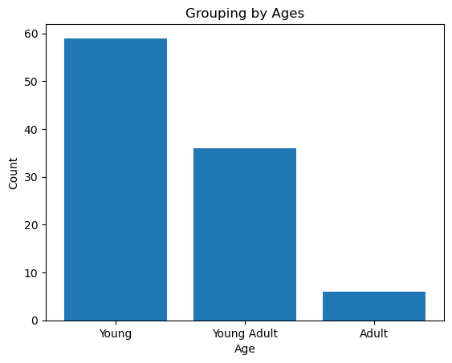

```python
plt.bar(group_names, df['binned_age'].value_counts())
plt.xlabel("Age")
plt.ylabel('Count')
plt.title("Grouping by Ages")
```

Therefore, let's examine some statistical measures for this column and create grouping based on the data contained therein:

```python
df[['age']].describe()
```

|  | age |
| --- | --- |
| count | 101.000000 |
| mean | 20.530000 |
| std | 2.483767 |
| min | 18.000000 |
| 25% | 18.000000 |
| 50% | 19.000000 |
| 75% | 23.000000 |
| max | 24.000000 |

Based on the descriptive statistics of the "age" column, obtained using the describe() method, we observe that the age range in the dataset varies from 18 (min) to 24 (max) years. Here is an explanation of how we chose to perform the grouping:

- Minimum and Maximum: The minimum age value is 18 years, and the maximum value is 24 years. We chose to use these values to define the boundaries of the grouping intervals.
- Meaningful Intervals: We opted to create two groups with meaningful intervals. The first group includes ages from 18 to 20 years, while the second group spans ages from 20 to 23 years.

This choice of grouping aims to create distinct categories that can be visualized, representing the different selected age ranges.

```python
# Use describe to obtain descriptive statistics
descriptive_statistics = df['age'].describe()

# Define group labels
group_names = ['18-20', '20-23']

# Apply binning using specific intervals to the 'age' column and create a new column 'binned_age_1'
df['binned_age_1'] = pd.cut(df['age'], bins=[18, 20, 23], labels=group_names, include_lowest=True)
```

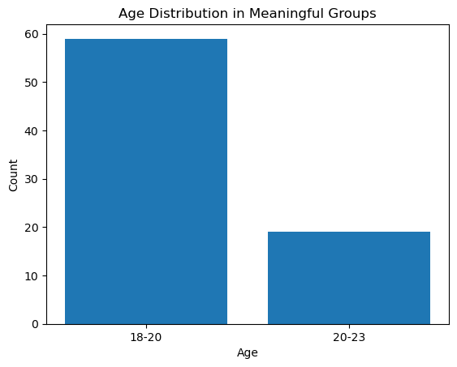

```python
plt.bar(group_names, df['binned_age_1'].value_counts())
plt.xlabel("Age")
plt.ylabel('Count')
plt.title("Age Distribution in Meaningful Groups")
```

Why perform this type of grouping?

Consider the last presented graph, and suppose that upon obtaining the dataset, we already have prior information that students aged between 18 and 20 years (including these age ranges) are more likely to attend the library. However, by observing the total number of students in the dataset, we cannot assess whether this group is significantly large or small relative to the total. By performing grouping and visualizing the graph, it becomes evident that the age range (18-20) is more than twice as large as the other group, providing a clearer perspective on the age distribution of students and highlighting the relevance of grouping to identify significant differences between age groups.

In more complex scenarios, other considerations should obviously be taken into account; but for our purposes, we have more than adequate and sufficient information here.

# 5 - Conversion of Categorical Data

As we continue to delve into data manipulation and preparation, we will now explore the conversion of categorical variables into indicators. This step aims to make these variables accessible to machine learning algorithms. This is a step that broadens the range of analytical techniques we can apply robustly to our dataset, contributing to our mission of understanding and obtaining insights from raw data.

**Motivation**:

- Converting categorical variables into indicators ensures that the variables are in the appropriate format.
- Choosing the correct data types not only optimizes computational performance but also facilitates mathematical operations and contributes to a clearer interpretation of variables.

**Implications**:

- Failure to perform conversion can result in inconsistencies in results, compromising the reliability of analyses.
- Standardizing data types facilitates interpretation and execution of specific operations, enhancing the effectiveness of analyses.

Next, we will explore type conversion in our dataset, using the `have_depression` column as a practical example. We will highlight the importance of this step in the manipulation and analysis process, exemplifying how this transformation contributes to the understanding and utility of the data. Let's analyze this column and determine the best approach in the process.

As we encounter different types of variables throughout this project, it is essential to address the issue of categorical variables, which assume qualitative values. Our focus now turns to the "`have_depression`n" column, a binary variable that reflects whether a student has depression or not. We chose this column due to its binary nature (YES, NO) and because it is a common representation in many datasets.

The current task directs us to convert the `have_depression` column into two distinct indicator variables: `have_depression_Yes` and `have_depression_No`. This operation will not only optimize the representation of this data but also serve as a practical and educational example of how this conversion can be applied to other similar variables.

At the end of this step, we will be able to assess how this transformation impacts our view of the dataset, contributing to the ongoing evolution of the analysis. Let's now explore this conversion.

```python
# Create the indicators
dummy_variable = pd.get_dummies(df['have_depression'], prefix='have_depression')

# Concatenate the indicators to the original DataFrame
df = pd.concat([df, dummy_variable], axis=1)

df.head(1)
```

|  | timestamp | gender | age | course | current_study_year | cgpa | marital_status | have_depression | have_anxiety | have_panic_attack | ... | height_cm | standardized_weight | standardized_height | normalized_age | normalized_weight | normalized_height | binned_age | binned_age_1 | have_depression_No | have_depression_Yes |
| --- | --- | --- | --- | --- | --- | --- | --- | --- | --- | --- | --- | --- | --- | --- | --- | --- | --- | --- | --- | --- | --- |
| 0 | NaT | Female | 18.0 | Engineering | year 1 | 3.245 | No | Yes | No | Yes | ... | 188 | 1.667306 | 1.667306 | 0.0 | 0.974359 | 0.974359 | Young | 18-20 | 0 | 1 |

1 rows × 22 columns

**Utilization of Indicators:**

The generated indicators, represented by the columns "has_depression_No" and "has_depression_Yes," will be useful for modeling and data analysis in contexts where binary categorical variables are relevant. This transformation enables more effective integration with machine learning algorithms, which often require the numerical representation of variables.

Here are some ways these indicators can be applied:

**1. Predictive Modeling:**

- Machine learning algorithms, such as logistic regression or decision trees, often require binary variables as input. These indicators provide a suitable representation for the "has_depression" attribute, allowing the efficient application of these algorithms.

**2. Exploratory Analysis:**

- Facilitate the visualization and interpretation of data. For example, we can analyze the distribution of students with and without depression in different categories, exploring patterns and trends. As an illustrative example, let's assume we have an additional column called "academic_performance" with values like "Good" and "Poor." We can now explore how academic performance is related to the presence or absence of depression.

**3. Comparison and Filtering:**

- Enable direct comparisons between groups of students with and without depression. This is useful for understanding how different factors may be related to mental health conditions.

**Generalization to Other Variables:**

This process of conversion to indicators can be extended to other binary categorical variables in the dataset, offering a consistent and effective approach in its preparation so that we can perform more advanced analyses.

By recognizing the importance of this step and understanding its applicability, we ensure that our data is ready for use in robust analytical applications. This contributes to achieving more comprehensive and accurate analyses.

# 6 - Final Considerations

As we conclude this educational Data Analysis project, we celebrate not only the completion of specific tasks but, more significantly, the acquisition of fundamental knowledge that forms a solid foundation for data manipulation and interpretation. Throughout the process, we practically explored and delved into concepts presented in the second week of the "Data Analysis with Python" course on Coursera.

The adopted approach highlighted the importance of a deep understanding of each step in data analysis. We didn't limit ourselves to just performing tasks but dedicated ourselves to understanding the underlying reasons for each decision made. This reflective approach not only strengthens our ability to apply specific techniques but also empowers us to face unexpected challenges more effectively.

As we conclude this project, far beyond celebrating acquired skills, we propel ourselves towards the future. Now equipped not only with specific techniques but also with a slightly deeper and more solid understanding of the principles that underpin such techniques.

Continuous learning and the practical application of this knowledge in real-world scenarios will be the key to constant evolution as data analysis professionals.

In summary, this project is not just a conclusion but the beginning of a broader journey. May we continue our pursuit, learning, and applying our knowledge to drive innovation and understanding in our community and beyond.

# 7 - Appendix

## 7.1 Understanding the Random Seed

In data science, it may be necessary to generate random numbers. However, to ensure consistency in results across different code executions, we use the random seed.

*Analogy with Boxes and Balls:*

Let's imagine we have several boxes, each containing a unique line of colored balls. Each time we draw a ball, the order is determined by the box itself. Here, the boxes represent different pseudo-random sequences.

The random seed is like choosing a specific box to start with. If we choose the same box (same seed) every time, we will draw the balls in the same order, as if they were patiently lined up, waiting to be drawn.

*Practical Example:*

Consider two boxes:

- Box 1 (Seed = 1): Blue, green, purple balls.
- Box 2 (Seed = 2): Purple, blue, green balls.

If we opt for Box 1 (seed = 1) `np.random.seed(1)`, we will draw the balls in the sequence blue, green, purple. If another person chooses the same Box 1, they will also draw the balls in the same predefined order. Analogously, if we opt for Box 2 (seed = 2) `np.random.seed(2)`, the sequence will be purple, blue, green, and anyone choosing Box 2 will draw the same predefined sequence.

The random seed (`np.random.seed(1)`) provides consistency, as if the balls were always arranged in a line, waiting to be drawn in the same order, regardless of who is drawing them.

This approach ensures the reproducibility of results, meaning no matter who "runs" the table we created, the results obtained will always be the same. This provides a solid foundation for comparable and reproducible analyses.

## 7.2 Decision on Columns Post Standardization - Keep or Remove?

### 7.2.1 Keep the Original Columns:

**Intuitive Interpretation:**

- If the direct interpretation of the original (non-standardized) values is more relevant to the target audience, it may be useful to keep the original columns.

**Visualization:**

- In some visualizations, it is more natural to work with data in their original scales. Keeping the original columns facilitates the creation of understandable graphs.

### 7.2.2 Remove the Original Columns:

**Space Saving:**

- If space economy or simplification of the dataset is a priority, removing the original columns after standardization may be beneficial.
- Redundancy Prevention: In some cases, keeping the original columns may be redundant, especially if all subsequent analyses are based on standardized data.

### 7.3 Hybrid Approach:

**Selective Choice:**

- One can choose to keep only the standardized columns or, in an exploratory context, keep both versions for comparative analysis.

Ultimately, the decision will depend on the nature of your project, presentation requirements, and specific preferences.

## 7.4 More on Normalization

Normalization is often used when preparing data for machine learning algorithms. Here are some reasons why this process is emphasized:

- **Comparable Scales:** Algorithms using distance measures can be influenced by the scale of the data. Normalization puts all variables on a comparable scale, preventing a variable with a larger scale from dominating the influence on results.
- **Faster Convergence:** Optimization algorithms, such as those used in neural networks, often converge faster on normalized data. This can lead to more efficient model training.
- **Mitigated Outlier Influence:** Normalization helps reduce the influence of outliers by putting all data on a more uniform scale.
- **More Intuitive Interpretation:** When data is normalized, the interpretation of coefficients or weights of the model becomes more intuitive, as variables are on comparable scales.
- **Data Preparation for Specific Algorithms:** Some algorithms, like neural networks, are sensitive to the scale of the data. Normalizing data helps create a more suitable input for these algorithms.

We suggest further research if the reader wants to know more details than what has been mentioned above.

## 7.5 Considerations on Binning

Before performing grouping (binning), we need to determine the appropriate interval range for the variable to be analyzed. The choice of interval range directly affects data interpretation and the effectiveness of grouping.

Here are some considerations when determining the interval range:

- **Domain Understanding:** Knowing the context of the problem and understanding the nature of the variable is necessary. For example, when grouping ages, it may be interesting to choose meaningful intervals, such as common age ranges (e.g., 0-18, 19-35, 36-50, etc.).
- **Data Distribution:** If the data is concentrated in a narrow range, it may be useful to choose smaller intervals to capture specific details. If the data is more dispersed, larger intervals may be more appropriate.
- **Analytical Objectives:** Consider the specific objectives of the analysis. Sometimes, broader intervals are chosen to provide an overview, while smaller intervals may be needed for more detailed analyses.
- **Relevance to the Target Audience:** Think about the target audience of the analysis. Meaningful and understandable intervals for the audience make interpretation more accessible.

Before implementing grouping, conducting exploratory data analysis can help inform the choice of the most appropriate interval range, however, this aspect is not included in the scope of this project.